# D208 TASK2 BY KOFFI GANU

Import Libraries

```python
# Libraries to help with reading and manipulating data
import numpy as np
import pandas as pd
from pandas import Series, DataFrame
# Visualization libraries
import seaborn as sns
import matplotlib.pyplot as plt
%matplotlib inline
# Statistics packages
import pylab
from pylab import rcParams
import statsmodels.api as sm
import statistics
from scipy import stats
# Scikit-learn
import sklearn
from sklearn import preprocessing
from sklearn.linear_model import LinearRegression
from sklearn.model_selection import train_test_split
from sklearn import metrics
from sklearn.metrics import classification_report
# To get diferent metric scores
from sklearn.metrics import (
    f1_score,
    accuracy_score,
    recall_score,
    precision_score,
    confusion_matrix,
    roc_auc_score,
    plot_confusion_matrix,
    precision_recall_curve,
    roc_curve,
)
# Import chisquare from SciPy.stats
from scipy.stats import chisquare
from scipy.stats import chi2_contingency
# Ignore Warning Code
import warnings
warnings.filterwarnings('ignore')
```

Reading Data set

```python
df = pd.read_csv("churn_clean.csv")
df.head()
```

|  | CaseOrder | Customer_id | Interaction | UID | City | State | County | Zip | Lat | Lng | ... | MonthlyCharge | Bandwidth_GB_Year | Item1 | Item2 | Item3 | Item4 | Item5 | Item6 | Item7 | Item8 |
| --- | --- | --- | --- | --- | --- | --- | --- | --- | --- | --- | --- | --- | --- | --- | --- | --- | --- | --- | --- | --- | --- |
| 0 | 1 | K409198 | aa90260b-4141-4a24-8e36-b04ce1f4f77b | e885b299883d4f9fb18e39c75155d990 | Point Baker | AK | Prince of Wales-Hyder | 99927 | 56.25100 | -133.37571 | ... | 172.455519 | 904.536110 | 5 | 5 | 5 | 3 | 4 | 4 | 3 | 4 |
| 1 | 2 | S120509 | fb76459f-c047-4a9d-8af9-e0f7d4ac2524 | f2de8bef964785f41a2959829830fb8a | West Branch | MI | Ogemaw | 48661 | 44.32893 | -84.24080 | ... | 242.632554 | 800.982766 | 3 | 4 | 3 | 3 | 4 | 3 | 4 | 4 |
| 2 | 3 | K191035 | 344d114c-3736-4be5-98f7-c72c281e2d35 | f1784cfa9f6d92ae816197eb175d3c71 | Yamhill | OR | Yamhill | 97148 | 45.35589 | -123.24657 | ... | 159.947583 | 2054.706961 | 4 | 4 | 2 | 4 | 4 | 3 | 3 | 3 |
| 3 | 4 | D90850 | abfa2b40-2d43-4994-b15a-989b8c79e311 | dc8a365077241bb5cd5ccd305136b05e | Del Mar | CA | San Diego | 92014 | 32.96687 | -117.24798 | ... | 119.956840 | 2164.579412 | 4 | 4 | 4 | 2 | 5 | 4 | 3 | 3 |
| 4 | 5 | K662701 | 68a861fd-0d20-4e51-a587-8a90407ee574 | aabb64a116e83fdc4befc1fbab1663f9 | Needville | TX | Fort Bend | 77461 | 29.38012 | -95.80673 | ... | 149.948316 | 271.493436 | 4 | 4 | 4 | 3 | 4 | 4 | 4 | 5 |

5 rows × 50 columns

Data shape

```python
df.shape
```

```
(10000, 50)
```

Data information

```python
df.info()
```

```
<class 'pandas.core.frame.DataFrame'>
RangeIndex: 10000 entries, 0 to 9999
Data columns (total 50 columns):
 #   Column                Non-Null Count  Dtype
---  ------                --------------  -----
 0   CaseOrder             10000 non-null  int64
 1   Customer_id           10000 non-null  object
 2   Interaction           10000 non-null  object
 3   UID                   10000 non-null  object
 4   City                  10000 non-null  object
 5   State                 10000 non-null  object
 6   County                10000 non-null  object
 7   Zip                   10000 non-null  int64
 8   Lat                   10000 non-null  float64
 9   Lng                   10000 non-null  float64
```

[output cut: 42 more lines]

Rename last 8 survey columns for better description of variables

```python
# Rename last 8 survey columns for better description of variables
df.rename(columns = {'Item1':'TimelyResponse',
'Item2':'Fixes',
'Item3':'Replacements',
'Item4':'Reliability',
'Item5':'Options',
'Item6':'Respectfulness',
'Item7':'Courteous',
'Item8':'Listening'},
inplace=True)
```

```python
df.head()
```

|  | CaseOrder | Customer_id | Interaction | UID | City | State | County | Zip | Lat | Lng | ... | MonthlyCharge | Bandwidth_GB_Year | TimelyResponse | Fixes | Replacements | Reliability | Options | Respectfulness | Courteous | Listening |
| --- | --- | --- | --- | --- | --- | --- | --- | --- | --- | --- | --- | --- | --- | --- | --- | --- | --- | --- | --- | --- | --- |
| 0 | 1 | K409198 | aa90260b-4141-4a24-8e36-b04ce1f4f77b | e885b299883d4f9fb18e39c75155d990 | Point Baker | AK | Prince of Wales-Hyder | 99927 | 56.25100 | -133.37571 | ... | 172.455519 | 904.536110 | 5 | 5 | 5 | 3 | 4 | 4 | 3 | 4 |
| 1 | 2 | S120509 | fb76459f-c047-4a9d-8af9-e0f7d4ac2524 | f2de8bef964785f41a2959829830fb8a | West Branch | MI | Ogemaw | 48661 | 44.32893 | -84.24080 | ... | 242.632554 | 800.982766 | 3 | 4 | 3 | 3 | 4 | 3 | 4 | 4 |
| 2 | 3 | K191035 | 344d114c-3736-4be5-98f7-c72c281e2d35 | f1784cfa9f6d92ae816197eb175d3c71 | Yamhill | OR | Yamhill | 97148 | 45.35589 | -123.24657 | ... | 159.947583 | 2054.706961 | 4 | 4 | 2 | 4 | 4 | 3 | 3 | 3 |
| 3 | 4 | D90850 | abfa2b40-2d43-4994-b15a-989b8c79e311 | dc8a365077241bb5cd5ccd305136b05e | Del Mar | CA | San Diego | 92014 | 32.96687 | -117.24798 | ... | 119.956840 | 2164.579412 | 4 | 4 | 4 | 2 | 5 | 4 | 3 | 3 |
| 4 | 5 | K662701 | 68a861fd-0d20-4e51-a587-8a90407ee574 | aabb64a116e83fdc4befc1fbab1663f9 | Needville | TX | Fort Bend | 77461 | 29.38012 | -95.80673 | ... | 149.948316 | 271.493436 | 4 | 4 | 4 | 3 | 4 | 4 | 4 | 5 |

5 rows × 50 columns

Remove less meaningful demographic variables from statistics description

```python
df = df.drop(columns=['CaseOrder', 'Customer_id', 'Interaction', 'UID', 'City','State', 'County', 'Zip', 'Lat', 'Lng',
'Area', 'TimeZone'])
```

Describe Churn dataset statistics

```python
df.describe()
```

|  | Population | Children | Age | Income | Outage_sec_perweek | Email | Contacts | Yearly_equip_failure | Tenure | MonthlyCharge | Bandwidth_GB_Year | TimelyResponse | Fixes | Replacements | Reliability | Options | Respectfulness | Courteous | Listening |
| --- | --- | --- | --- | --- | --- | --- | --- | --- | --- | --- | --- | --- | --- | --- | --- | --- | --- | --- | --- |
| count | 10000.000000 | 10000.0000 | 10000.000000 | 10000.000000 | 10000.000000 | 10000.000000 | 10000.000000 | 10000.000000 | 10000.000000 | 10000.000000 | 10000.000000 | 10000.000000 | 10000.000000 | 10000.000000 | 10000.000000 | 10000.000000 | 10000.000000 | 10000.000000 | 10000.000000 |
| mean | 9756.562400 | 2.0877 | 53.078400 | 39806.926771 | 10.001848 | 12.016000 | 0.994200 | 0.398000 | 34.526188 | 172.624816 | 3392.341550 | 3.490800 | 3.505100 | 3.487000 | 3.497500 | 3.492900 | 3.497300 | 3.509500 | 3.495600 |
| std | 14432.698671 | 2.1472 | 20.698882 | 28199.916702 | 2.976019 | 3.025898 | 0.988466 | 0.635953 | 26.443063 | 42.943094 | 2185.294852 | 1.037797 | 1.034641 | 1.027977 | 1.025816 | 1.024819 | 1.033586 | 1.028502 | 1.028633 |
| min | 0.000000 | 0.0000 | 18.000000 | 348.670000 | 0.099747 | 1.000000 | 0.000000 | 0.000000 | 1.000259 | 79.978860 | 155.506715 | 1.000000 | 1.000000 | 1.000000 | 1.000000 | 1.000000 | 1.000000 | 1.000000 | 1.000000 |
| 25% | 738.000000 | 0.0000 | 35.000000 | 19224.717500 | 8.018214 | 10.000000 | 0.000000 | 0.000000 | 7.917694 | 139.979239 | 1236.470827 | 3.000000 | 3.000000 | 3.000000 | 3.000000 | 3.000000 | 3.000000 | 3.000000 | 3.000000 |
| 50% | 2910.500000 | 1.0000 | 53.000000 | 33170.605000 | 10.018560 | 12.000000 | 1.000000 | 0.000000 | 35.430507 | 167.484700 | 3279.536903 | 3.000000 | 4.000000 | 3.000000 | 3.000000 | 3.000000 | 3.000000 | 4.000000 | 3.000000 |
| 75% | 13168.000000 | 3.0000 | 71.000000 | 53246.170000 | 11.969485 | 14.000000 | 2.000000 | 1.000000 | 61.479795 | 200.734725 | 5586.141369 | 4.000000 | 4.000000 | 4.000000 | 4.000000 | 4.000000 | 4.000000 | 4.000000 | 4.000000 |
| max | 111850.000000 | 10.0000 | 89.000000 | 258900.700000 | 21.207230 | 23.000000 | 7.000000 | 6.000000 | 71.999280 | 290.160419 | 7158.981530 | 7.000000 | 7.000000 | 8.000000 | 7.000000 | 7.000000 | 8.000000 | 7.000000 | 8.000000 |

Convert object variable to category variable

```python
cols = df.select_dtypes(['object'])
for i in cols.columns:
    df[i] = df[i].astype('category')
```

```python
df.info()
```

```
<class 'pandas.core.frame.DataFrame'>
RangeIndex: 10000 entries, 0 to 9999
Data columns (total 38 columns):
 #   Column                Non-Null Count  Dtype
---  ------                --------------  -----
 0   Population            10000 non-null  int64
 1   Job                   10000 non-null  category
 2   Children              10000 non-null  int64
 3   Age                   10000 non-null  int64
 4   Income                10000 non-null  float64
 5   Marital               10000 non-null  category
 6   Gender                10000 non-null  category
 7   Churn                 10000 non-null  category
 8   Outage_sec_perweek    10000 non-null  float64
 9   Email                 10000 non-null  int64
```

[output cut: 30 more lines]

Univariate visualization.

Numerical variable

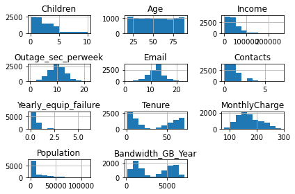

```python
# Create histograms of contiuous variables
df[['Children', 'Age', 'Income', 'Outage_sec_perweek', 'Email',
'Contacts', 'Yearly_equip_failure', 'Tenure', 'MonthlyCharge', 'Population',
'Bandwidth_GB_Year']].hist()
#plt.savefig('churn_pyplot.jpg')
plt.tight_layout()
```

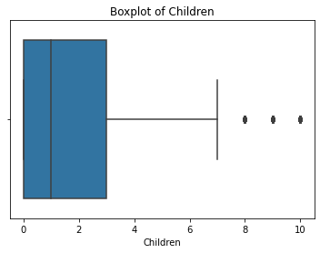

```python
sns.boxplot(df["Children"])
plt.title("Boxplot of Children")
plt.show()
```

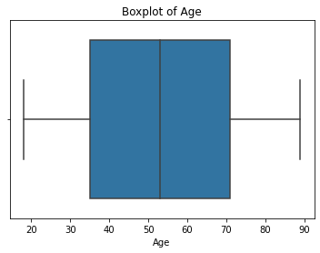

```python
sns.boxplot(df["Age"])
plt.title("Boxplot of Age")
plt.show()
```

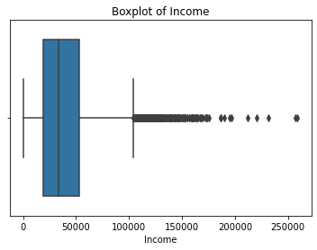

```python
sns.boxplot(df["Income"])
plt.title("Boxplot of Income")
plt.show()
```

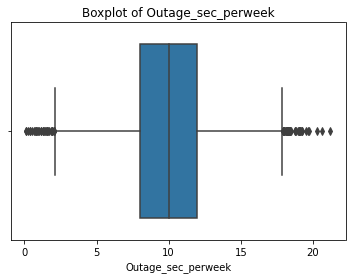

```python
sns.boxplot(df["Outage_sec_perweek"])
plt.title("Boxplot of Outage_sec_perweek")
plt.show()
```

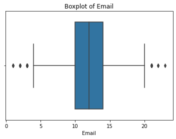

```python
sns.boxplot(df["Email"])
plt.title("Boxplot of Email")
plt.show()
```

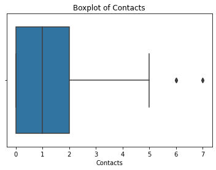

```python
sns.boxplot(df["Contacts"])
plt.title("Boxplot of Contacts")
plt.show()
```

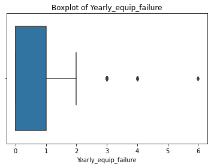

```python
sns.boxplot(df["Yearly_equip_failure"])
plt.title("Boxplot of Yearly_equip_failure")
plt.show()
```

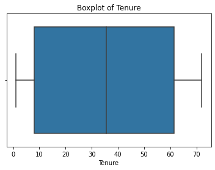

```python
sns.boxplot(df["Tenure"])
plt.title("Boxplot of Tenure")
plt.show()
```

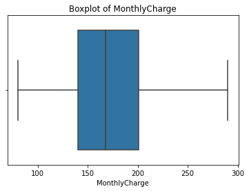

```python
sns.boxplot(df["MonthlyCharge"])
plt.title("Boxplot of MonthlyCharge")
plt.show()
```

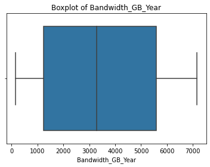

```python
sns.boxplot(df["Bandwidth_GB_Year"])
plt.title("Boxplot of Bandwidth_GB_Year")
plt.show()
```

Categorical variable

```python
 # Function to create barplots that indicate percentage for each category.
def bar_perc(plot, feature):
    '''
    plot
    feature: 1-d categorical feature array
    '''
    total = len(feature) # length of the column
    for p in ax.patches:
        percentage = '{:.1f}%'.format(100 * p.get_height()/total) # percentage of each class of the category
        x = p.get_x() + p.get_width() / 2 - 0.05 # width of the plot
        y = p.get_y() + p.get_height()           # hieght of the plot
        ax.annotate(percentage, (x, y), size = 12) # annotate the percantage
```

```
Female       5025
Male         4744
Nonbinary     231
Name: Gender, dtype: int64
```

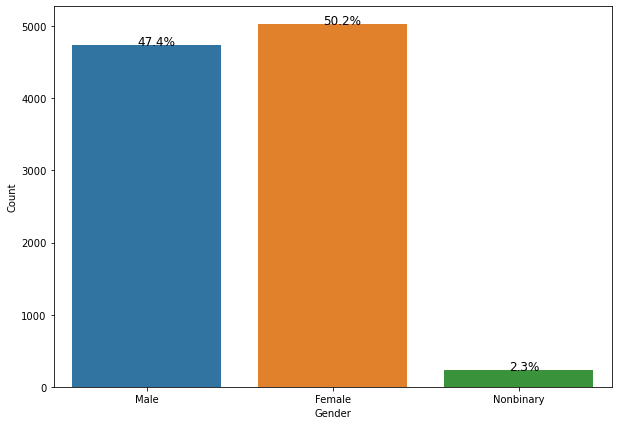

```python
plt.figure(figsize=(10,7))
ax = sns.countplot(df['Gender'])
plt.xlabel('Gender')
plt.ylabel('Count')
bar_perc(ax,df['Gender'])
df['Gender'].value_counts()
```

```
No     7350
Yes    2650
Name: Churn, dtype: int64
```

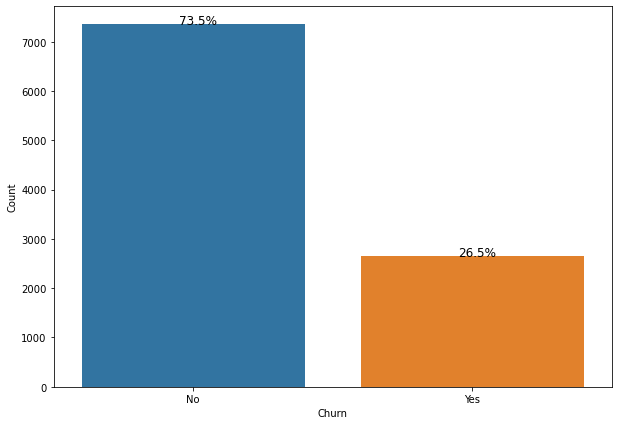

```python
plt.figure(figsize=(10,7))
ax = sns.countplot(df['Churn'])
plt.xlabel('Churn')
plt.ylabel('Count')
bar_perc(ax,df['Churn'])
df['Churn'].value_counts()
```

```
No     8321
Yes    1679
Name: Techie, dtype: int64
```

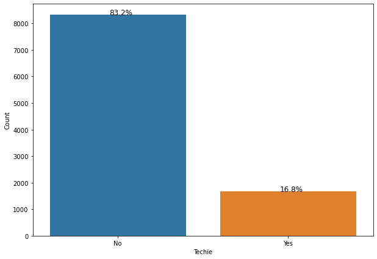

```python
plt.figure(figsize=(10,7))
ax = sns.countplot(df['Techie'])
plt.xlabel('Techie')
plt.ylabel('Count')
bar_perc(ax,df['Techie'])
df['Techie'].value_counts()
```

```
Month-to-month    5456
Two Year          2442
One year          2102
Name: Contract, dtype: int64
```

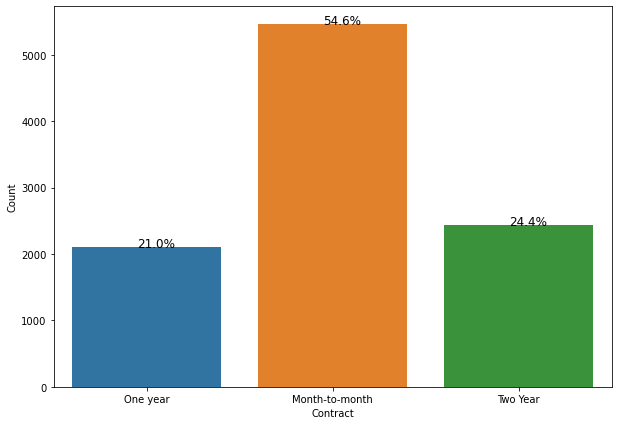

```python
plt.figure(figsize=(10,7))
ax = sns.countplot(df['Contract'])
plt.xlabel('Contract')
plt.ylabel('Count')
bar_perc(ax,df['Contract'])
df['Contract'].value_counts()
```

```
No     5166
Yes    4834
Name: Port_modem, dtype: int64
```

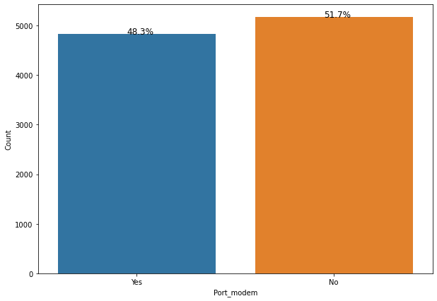

```python
plt.figure(figsize=(10,7))
ax = sns.countplot(df['Port_modem'])
plt.xlabel('Port_modem')
plt.ylabel('Count')
bar_perc(ax,df['Port_modem'])
df['Port_modem'].value_counts()
```

```
Divorced         2092
Widowed          2027
Separated        2014
Never Married    1956
Married          1911
Name: Marital, dtype: int64
```

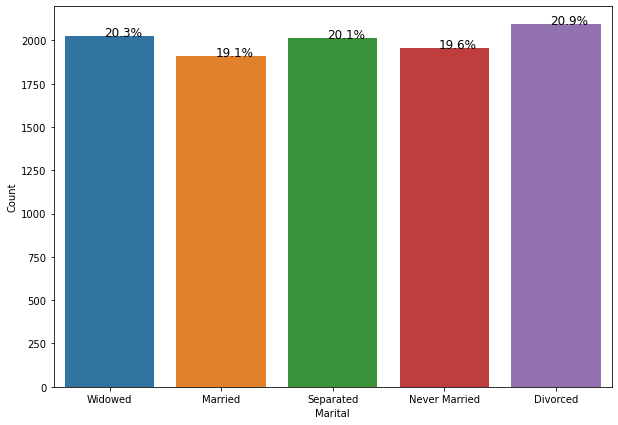

```python
plt.figure(figsize=(10,7))
ax = sns.countplot(df['Marital'])
plt.xlabel('Marital')
plt.ylabel('Count')
bar_perc(ax,df['Marital'])
df['Marital'].value_counts()
```

```
No     7009
Yes    2991
Name: Tablet, dtype: int64
```

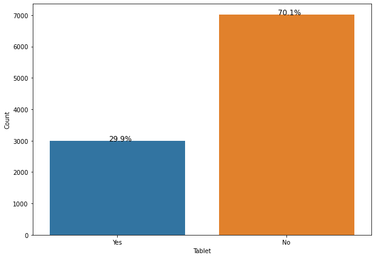

```python
plt.figure(figsize=(10,7))
ax = sns.countplot(df['Tablet'])
plt.xlabel('Tablet')
plt.ylabel('Count')
bar_perc(ax,df['Tablet'])
df['Tablet'].value_counts()
```

BIVARIATE visualization

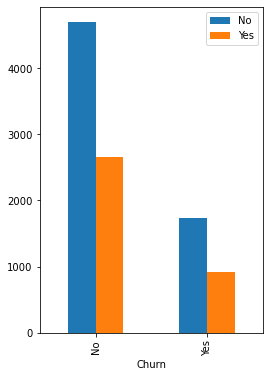

```python
df2= pd.crosstab(index=df['Churn'], columns=df['OnlineSecurity'])
df2.plot(kind="bar", figsize=(4,6))
plt.legend()
plt.show()
```

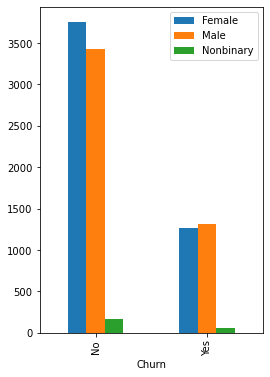

```python
df2= pd.crosstab(index=df['Churn'], columns=df['Gender'])
df2.plot(kind="bar", figsize=(4,6))
plt.legend()
plt.show()
```

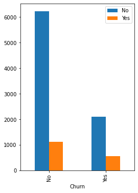

```python
df2= pd.crosstab(index=df['Churn'], columns=df['Techie'])
df2.plot(kind="bar", figsize=(4,6))
plt.legend()
plt.show()
```

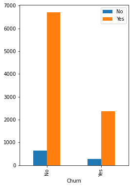

```python
df2= pd.crosstab(index=df['Churn'], columns=df['Phone'])
df2.plot(kind="bar", figsize=(4,6))
plt.legend()
plt.show()
```

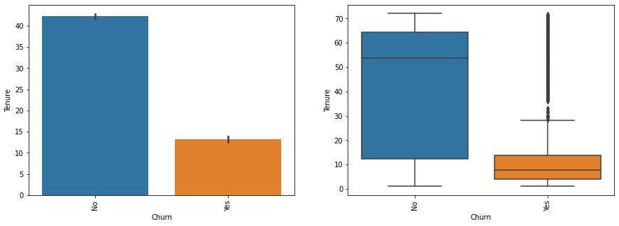

```python
plt.figure(figsize=(15, 5))

plt.subplot(1, 2, 1)
sns.barplot(data=df, y="Tenure", x="Churn")
plt.xticks(rotation=90)

plt.subplot(1, 2, 2)
sns.boxplot(data=df, y="Tenure", x="Churn")
plt.xticks(rotation=90)

plt.show()
```

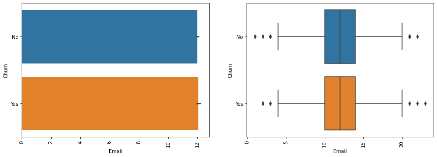

```python
plt.figure(figsize=(15, 5))

plt.subplot(1, 2, 1)
sns.barplot(data=df, y="Churn", x="Email")
plt.xticks(rotation=90)

plt.subplot(1, 2, 2)
sns.boxplot(data=df, y="Churn", x="Email")
plt.xticks(rotation=90)

plt.show()
```

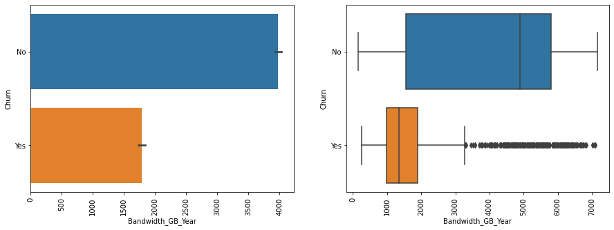

```python
plt.figure(figsize=(15, 5))

plt.subplot(1, 2, 1)
sns.barplot(data=df, y="Churn", x="Bandwidth_GB_Year")
plt.xticks(rotation=90)

plt.subplot(1, 2, 2)
sns.boxplot(data=df, y="Churn", x="Bandwidth_GB_Year")
plt.xticks(rotation=90)

plt.show()
```

Checking for missing values

```python
# Discover missing data points within dataset
df = df.isnull().sum()
print(df)
```

[output not shown]

Checking for outliers

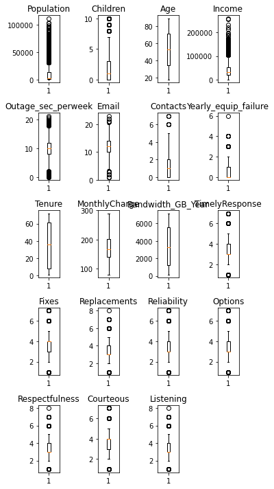

```python
numeric_columns = df.select_dtypes(include=np.number).columns.tolist()
plt.figure(figsize=(5, 10))

for i, variable in enumerate(numeric_columns):
    plt.subplot(5, 4, i + 1)
    plt.boxplot(df[variable], whis=1.5)
    plt.tight_layout()
    plt.title(variable)

plt.show()
```

Treating all outliers

```python
def treat_outliers(df, col):
    """
    treats outliers in a variable
    col: str, name of the numerical variable
    df: dataframe
    col: name of the column
    """
    Q1 = df[col].quantile(0.25)  # 25th quantile
    Q3 = df[col].quantile(0.75)  # 75th quantile
    IQR = Q3 - Q1
    Lower_Whisker = Q1 - 1.5 * IQR
    Upper_Whisker = Q3 + 1.5 * IQR

    # all the values smaller than Lower_Whisker will be assigned the value of Lower_Whisker
    # all the values greater than Upper_Whisker will be assigned the value of Upper_Whisker
    df[col] = np.clip(df[col], Lower_Whisker, Upper_Whisker)

    return df


def treat_outliers_all(df, col_list):
    """
    treat outlier in all numerical variables
    col_list: list of numerical variables
    df: data frame
    """
    for c in col_list:
        df = treat_outliers(df, c)

    return df
```

```python
numerical_col = df.select_dtypes(include=np.number).columns.tolist()
df = treat_outliers_all(df, numerical_col)
```

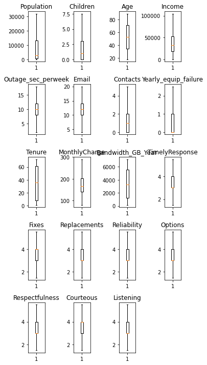

```python
numeric_columns = df.select_dtypes(include=np.number).columns.tolist()
plt.figure(figsize=(5, 10))

for i, variable in enumerate(numeric_columns):
    plt.subplot(5, 4, i + 1)
    plt.boxplot(df[variable], whis=1.5)
    plt.tight_layout()
    plt.title(variable)

plt.show()
```

Data Preparation for modeling

We want to predict customer churn.

Before we proceed to build a model, we'll have to encode categorical features. We'll split the data into train and test to be able to evaluate the model that we build on the train data

```python
df = df.drop(columns=['Population', 'Job', 'Marital', 'PaymentMethod'])
```

Prepared data set

```python
# Extract prepared Clean dataset
df.to_csv('df_clean.csv')
```

```python
print(df)
```

```
      Children  Age    Income  Gender Churn  Outage_sec_perweek  Email  \
0          0.0   68  28561.99    Male    No            7.978323     10
1          1.0   27  21704.77  Female   Yes           11.699080     12
2          4.0   50   9609.57  Female    No           10.752800      9
3          1.0   48  18925.23    Male    No           14.913540     15
4          0.0   83  40074.19    Male   Yes            8.147417     16
...        ...  ...       ...     ...   ...                 ...    ...
9995       3.0   23  55723.74    Male    No            9.415935     12
9996       4.0   48  34129.34    Male    No            6.740547     15
9997       1.0   48  45983.43  Female    No            6.590911     10
9998       1.0   39  16667.58    Male    No           12.071910     14
9999       1.0   28   9020.92    Male    No           11.754720     17

      Contacts  Yearly_equip_failure Techie  ... MonthlyCharge  \
0            0                   1.0     No  ...    172.455519
```

[output cut: 38 more lines]

```python
X = df.drop(["Churn"], axis=1)
Y = df["Churn"]
Y = Y.map({'Yes': 1, 'No': 0}).astype(int)

X = pd.get_dummies(X, drop_first=True)

# Splitting data in train and test sets
X_train, X_test, y_train, y_test = train_test_split(
    X, Y, test_size=0.30, random_state=1
)
```

```python
print("Shape of Training set : ", X_train.shape)
print("Shape of test set : ", X_test.shape)
print("Percentage of classes in training set:")
print(y_train.value_counts(normalize=True))
print("Percentage of classes in test set:")
print(y_test.value_counts(normalize=True))
```

```
Shape of Training set :  (7000, 36)
Shape of test set :  (3000, 36)
Percentage of classes in training set:
0    0.739429
1    0.260571
Name: Churn, dtype: float64
Percentage of classes in test set:
0    0.724667
1    0.275333
Name: Churn, dtype: float64
```

Logistic Regression (with statsmodels library)

```python
X = df.drop(["Churn"], axis=1)
Y = df["Churn"]
Y = Y.map({'Yes': 1, 'No': 0}).astype(int)

X = pd.get_dummies(X, drop_first=True)

# adding constant
X = sm.add_constant(X)

# Splitting data in train and test sets
X_train, X_test, y_train, y_test = train_test_split(
    X, Y, test_size=0.30, random_state=1
)
```

Initial Logistic Regression Model

```python
# fitting logistic regression model
logit = sm.Logit(y_train, X_train)
lg = logit.fit()

print(lg.summary())
```

```
Optimization terminated successfully.
         Current function value: 0.215810
         Iterations 9
                           Logit Regression Results
==============================================================================
Dep. Variable:                  Churn   No. Observations:                 7000
Model:                          Logit   Df Residuals:                     6963
Method:                           MLE   Df Model:                           36
Date:                Thu, 23 Feb 2023   Pseudo R-squ.:                  0.6238
Time:                        09:44:04   Log-Likelihood:                -1510.7
converged:                       True   LL-Null:                       -4015.6
Covariance Type:            nonrobust   LLR p-value:                     0.000
===============================================================================================
                                  coef    std err          z      P>|z|      [0.025      0.975]
-----------------------------------------------------------------------------------------------
const                          -4.5445      1.420     -3.200      0.001      -7.328      -1.761
Children                       -0.0086      0.132     -0.065      0.948      -0.267       0.250
Age                             0.0036      0.013      0.270      0.787      -0.022       0.029
Income                       1.036e-06   1.81e-06      0.571      0.568   -2.52e-06    4.59e-06
Outage_sec_perweek             -0.0027      0.016     -0.174      0.862      -0.034       0.028
Email                          -0.0018      0.015     -0.114      0.909      -0.032       0.028
Contacts                        0.0699      0.047      1.490      0.136      -0.022       0.162
Yearly_equip_failure           -0.0800      0.074     -1.084      0.279      -0.225       0.065
Tenure                         -0.2240      0.324     -0.692      0.489      -0.858       0.410
MonthlyCharge                   0.0315      0.013      2.436      0.015       0.006       0.057
Bandwidth_GB_Year               0.0013      0.004      0.331      0.741      -0.006       0.009
TimelyResponse                 -0.0221      0.069     -0.323      0.747      -0.156       0.112
Fixes                           0.0094      0.064      0.147      0.883      -0.117       0.135
Replacements                    0.0192      0.059      0.325      0.745      -0.097       0.135
Reliability                    -0.0399      0.053     -0.756      0.450      -0.143       0.064
Options                        -0.0404      0.056     -0.723      0.470      -0.150       0.069
Respectfulness                 -0.0385      0.057     -0.674      0.500      -0.150       0.073
Courteous                       0.0033      0.055      0.061      0.952      -0.104       0.111
Listening                      -0.0006      0.051     -0.012      0.990      -0.101       0.100
Gender_Male                     0.1864      0.263      0.708      0.479      -0.329       0.702
Gender_Nonbinary               -0.0708      0.332     -0.213      0.831      -0.722       0.581
Techie_Yes                      1.0562      0.123      8.601      0.000       0.816       1.297
Contract_One year              -3.3985      0.154    -22.059      0.000      -3.700      -3.097
Contract_Two Year              -3.5187      0.154    -22.888      0.000      -3.820      -3.217
Port_modem_Yes                  0.0938      0.093      1.008      0.313      -0.089       0.276
Tablet_Yes                     -0.0358      0.101     -0.353      0.724      -0.234       0.163
InternetService_Fiber Optic    -1.4084      1.873     -0.752      0.452      -5.079       2.263
InternetService_None           -0.5253      1.495     -0.351      0.725      -3.455       2.405
Phone_Yes                      -0.2260      0.160     -1.414      0.157      -0.539       0.087
Multiple_Yes                    0.5604      0.229      2.446      0.014       0.111       1.009
OnlineSecurity_Yes             -0.3990      0.284     -1.406      0.160      -0.955       0.157
OnlineBackup_Yes                0.0590      0.190      0.311      0.756      -0.313       0.431
DeviceProtection_Yes           -0.0206      0.221     -0.093      0.926      -0.454       0.413
TechSupport_Yes                -0.1635      0.173     -0.944      0.345      -0.503       0.176
StreamingTV_Yes                 1.2905      0.487      2.649      0.008       0.336       2.245
StreamingMovies_Yes             1.5848      0.386      4.102      0.000       0.827       2.342
PaperlessBilling_Yes            0.1222      0.094      1.296      0.195      -0.063       0.307
===============================================================================================
```

Checking model performance

```python
# defining a function to compute different metrics to check performance of a classification model built using statsmodels
def model_performance_classification_statsmodels(
    model, predictors, target, threshold=0.5
):
    """
    Function to compute different metrics to check classification model performance

    model: classifier
    predictors: independent variables
    target: dependent variable
    threshold: threshold for classifying the observation as class 1
    """

    # checking which probabilities are greater than threshold
    pred_temp = model.predict(predictors) > threshold
    # rounding off the above values to get classes
    pred = np.round(pred_temp)

    acc = accuracy_score(target, pred)  # to compute Accuracy
    recall = recall_score(target, pred)  # to compute Recall
    precision = precision_score(target, pred)  # to compute Precision
    f1 = f1_score(target, pred)  # to compute F1-score

    # creating a dataframe of metrics
    df_perf = pd.DataFrame(
        {"Accuracy": acc, "Recall": recall, "Precision": precision, "F1": f1,},
        index=[0],
    )

    return df_perf
```

```python
# defining a function to plot the confusion_matrix of a classification model


def confusion_matrix_statsmodels(model, predictors, target, threshold=0.5):
    """
    To plot the confusion_matrix with percentages

    model: classifier
    predictors: independent variables
    target: dependent variable
    threshold: threshold for classifying the observation as class 1
    """
    y_pred = model.predict(predictors) > threshold
    cm = confusion_matrix(target, y_pred)
    labels = np.asarray(
        [
            ["{0:0.0f}".format(item) + "\n{0:.2%}".format(item / cm.flatten().sum())]
            for item in cm.flatten()
        ]
    ).reshape(2, 2)

    plt.figure(figsize=(6, 4))
    sns.heatmap(cm, annot=labels, fmt="")
    plt.ylabel("True label")
    plt.xlabel("Predicted label")
```

```python
print("Training performance:")
model_performance_classification_statsmodels(lg, X_train, y_train)
```

```
Training performance:
```

|  | Accuracy | Recall | Precision | F1 |
| --- | --- | --- | --- | --- |
| 0 | 0.907286 | 0.808114 | 0.831359 | 0.819572 |

Creating confusion matrix for initial Logistic Regression

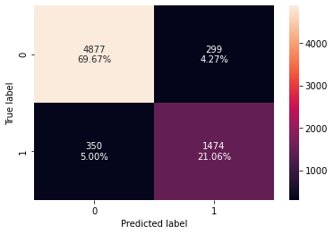

```python
# creating confusion matrix
confusion_matrix_statsmodels(lg, X_train, y_train)
```

Selected feature variable by dropping variable with high p-value

```python
# initial list of columns
cols = X_train.columns.tolist()

# setting an initial max p-value
max_p_value = 1

while len(cols) > 0:
    # defining the train set
    x_train_aux = X_train[cols]

    # fitting the model
    model = sm.OLS(y_train, x_train_aux).fit()

    # getting the p-values and the maximum p-value
    p_values = model.pvalues
    max_p_value = max(p_values)

    # name of the variable with maximum p-value
    feature_with_p_max = p_values.idxmax()

    if max_p_value > 0.05:
        cols.remove(feature_with_p_max)
    else:
        break

selected_features = cols
print(selected_features)
```

```
['const', 'Children', 'Age', 'Tenure', 'MonthlyCharge', 'Bandwidth_GB_Year', 'Gender_Male', 'Techie_Yes', 'Contract_One year', 'Contract_Two Year', 'InternetService_Fiber Optic', 'InternetService_None', 'Multiple_Yes', 'OnlineBackup_Yes', 'TechSupport_Yes', 'StreamingTV_Yes', 'StreamingMovies_Yes']
```

```python
X_train1 = X_train[selected_features]
X_test1 = X_test[selected_features]
```

Reduced Logistic Regression Model

```python
logit1 = sm.Logit(y_train, X_train1)
lg1 = logit1.fit()
print(lg1.summary())
```

```
Optimization terminated successfully.
         Current function value: 0.216938
         Iterations 9
                           Logit Regression Results
==============================================================================
Dep. Variable:                  Churn   No. Observations:                 7000
Model:                          Logit   Df Residuals:                     6983
Method:                           MLE   Df Model:                           16
Date:                Thu, 23 Feb 2023   Pseudo R-squ.:                  0.6218
Time:                        09:44:56   Log-Likelihood:                -1518.6
converged:                       True   LL-Null:                       -4015.6
Covariance Type:            nonrobust   LLR p-value:                     0.000
===============================================================================================
                                  coef    std err          z      P>|z|      [0.025      0.975]
-----------------------------------------------------------------------------------------------
const                          -4.0905      0.501     -8.161      0.000      -5.073      -3.108
Children                        0.1222      0.047      2.615      0.009       0.031       0.214
Age                            -0.0097      0.005     -2.094      0.036      -0.019      -0.001
Tenure                          0.1114      0.100      1.118      0.264      -0.084       0.307
MonthlyCharge                   0.0482      0.007      6.601      0.000       0.034       0.062
Bandwidth_GB_Year              -0.0028      0.001     -2.284      0.022      -0.005      -0.000
Gender_Male                     0.4520      0.123      3.680      0.000       0.211       0.693
Techie_Yes                      1.0440      0.122      8.544      0.000       0.805       1.283
Contract_One year              -3.3714      0.153    -22.048      0.000      -3.671      -3.072
Contract_Two Year              -3.5082      0.153    -22.882      0.000      -3.809      -3.208
InternetService_Fiber Optic    -3.4291      0.637     -5.381      0.000      -4.678      -2.180
InternetService_None           -2.0088      0.458     -4.382      0.000      -2.907      -1.110
Multiple_Yes                    0.3001      0.199      1.507      0.132      -0.090       0.690
OnlineBackup_Yes                0.0590      0.136      0.433      0.665      -0.208       0.326
TechSupport_Yes                -0.3700      0.127     -2.910      0.004      -0.619      -0.121
StreamingTV_Yes                 1.4999      0.222      6.751      0.000       1.064       1.935
StreamingMovies_Yes             1.5571      0.262      5.948      0.000       1.044       2.070
===============================================================================================
```

All the variables left a significant (P-value<0.05) except OnlineBackup_yes, Tenure, and Multiple_yes with p-value > 0.05. We will drop them from our predictor variables before make the final model.

```python
X_train2 = X_train1.drop(columns=['Tenure', 'Multiple_Yes', 'OnlineBackup_Yes'])
```

Final reduced Logistic Regression model

```python
logit2 = sm.Logit(y_train, X_train2)
lg2 = logit2.fit()
print(lg2.summary())
```

```
Optimization terminated successfully.
         Current function value: 0.217556
         Iterations 9
                           Logit Regression Results
==============================================================================
Dep. Variable:                  Churn   No. Observations:                 7000
Model:                          Logit   Df Residuals:                     6986
Method:                           MLE   Df Model:                           13
Date:                Thu, 23 Feb 2023   Pseudo R-squ.:                  0.6208
Time:                        09:54:01   Log-Likelihood:                -1522.9
converged:                       True   LL-Null:                       -4015.6
Covariance Type:            nonrobust   LLR p-value:                     0.000
===============================================================================================
                                  coef    std err          z      P>|z|      [0.025      0.975]
-----------------------------------------------------------------------------------------------
const                          -4.9662      0.317    -15.667      0.000      -5.587      -4.345
Children                        0.0756      0.024      3.197      0.001       0.029       0.122
Age                            -0.0053      0.002     -2.351      0.019      -0.010      -0.001
MonthlyCharge                   0.0493      0.002     20.479      0.000       0.045       0.054
Bandwidth_GB_Year              -0.0014   4.35e-05    -32.914      0.000      -0.002      -0.001
Gender_Male                     0.3687      0.093      3.980      0.000       0.187       0.550
Techie_Yes                      1.0443      0.122      8.570      0.000       0.805       1.283
Contract_One year              -3.3703      0.153    -22.039      0.000      -3.670      -3.071
Contract_Two Year              -3.5087      0.154    -22.809      0.000      -3.810      -3.207
InternetService_Fiber Optic    -2.8837      0.134    -21.452      0.000      -3.147      -2.620
InternetService_None           -1.4289      0.136    -10.471      0.000      -1.696      -1.161
TechSupport_Yes                -0.3900      0.098     -3.973      0.000      -0.582      -0.198
StreamingTV_Yes                 1.1228      0.130      8.628      0.000       0.868       1.378
StreamingMovies_Yes             1.1923      0.144      8.252      0.000       0.909       1.476
===============================================================================================
```

All the variables left a significant (P-value<0.05) So we can say that lg2 is the best model for making any inference.

Coefficient interpretations The coefficient of Children, MonthlyCharge, GenderMale, Techie_yes, StreamingTV_Yes, StreamingMovies_Yes are positive. So, we can say that these variables contribute to customer churn. Coefficient of Age, Bandwidth_GB_Year, Contract_One year, Contract_Two Year, InternetService_Fiber Optic, InternetService_None, TechSupport_Yes are negative. So, these variables will not lead to customer churn.

```python
print("Training performance:")
model_performance_classification_statsmodels(lg2, X_train2, y_train)
```

```
Training performance:
```

|  | Accuracy | Recall | Precision | F1 |
| --- | --- | --- | --- | --- |
| 0 | 0.904857 | 0.802632 | 0.827119 | 0.814691 |

Creating confusion matrix for reduced Logistic Regression

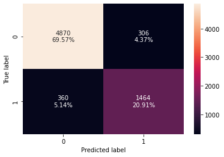

```python
# creating confusion matrix
confusion_matrix_statsmodels(lg2, X_train2, y_train)
```